# Importation du dataset :

```python
import pandas as pd
import numpy as np
import matplotlib.pyplot as plt
import seaborn as sns
from sklearn.impute import SimpleImputer
from scipy.stats import gaussian_kde

sns.set(style="whitegrid")
df = pd.read_csv('speeddating.csv', na_values = '?')
df
```

|  | has_null | wave | gender | age | age_o | d_age | d_d_age | race | race_o | samerace | ... | d_expected_num_interested_in_me | d_expected_num_matches | like | guess_prob_liked | d_like | d_guess_prob_liked | met | decision | decision_o | match |
| --- | --- | --- | --- | --- | --- | --- | --- | --- | --- | --- | --- | --- | --- | --- | --- | --- | --- | --- | --- | --- | --- |
| 0 | 0 | 1 | female | 21.0 | 27.0 | 6 | [4-6] | 'Asian/Pacific Islander/Asian-American' | European/Caucasian-American | 0 | ... | [0-3] | [3-5] | 7.0 | 6.0 | [6-8] | [5-6] | 0.0 | 1 | 0 | 0 |
| 1 | 0 | 1 | female | 21.0 | 22.0 | 1 | [0-1] | 'Asian/Pacific Islander/Asian-American' | European/Caucasian-American | 0 | ... | [0-3] | [3-5] | 7.0 | 5.0 | [6-8] | [5-6] | 1.0 | 1 | 0 | 0 |
| 2 | 1 | 1 | female | 21.0 | 22.0 | 1 | [0-1] | 'Asian/Pacific Islander/Asian-American' | 'Asian/Pacific Islander/Asian-American' | 1 | ... | [0-3] | [3-5] | 7.0 | NaN | [6-8] | [0-4] | 1.0 | 1 | 1 | 1 |
| 3 | 0 | 1 | female | 21.0 | 23.0 | 2 | [2-3] | 'Asian/Pacific Islander/Asian-American' | European/Caucasian-American | 0 | ... | [0-3] | [3-5] | 7.0 | 6.0 | [6-8] | [5-6] | 0.0 | 1 | 1 | 1 |
| 4 | 0 | 1 | female | 21.0 | 24.0 | 3 | [2-3] | 'Asian/Pacific Islander/Asian-American' | 'Latino/Hispanic American' | 0 | ... | [0-3] | [3-5] | 6.0 | 6.0 | [6-8] | [5-6] | 0.0 | 1 | 1 | 1 |
| ... | ... | ... | ... | ... | ... | ... | ... | ... | ... | ... | ... | ... | ... | ... | ... | ... | ... | ... | ... | ... | ... |
| 8373 | 1 | 21 | male | 25.0 | 26.0 | 1 | [0-1] | European/Caucasian-American | 'Latino/Hispanic American' | 0 | ... | [0-3] | [3-5] | 2.0 | 5.0 | [0-5] | [5-6] | 0.0 | 0 | 1 | 0 |
| 8374 | 1 | 21 | male | 25.0 | 24.0 | 1 | [0-1] | European/Caucasian-American | Other | 0 | ... | [0-3] | [3-5] | 4.0 | 4.0 | [0-5] | [0-4] | 0.0 | 0 | 0 | 0 |
| 8375 | 1 | 21 | male | 25.0 | 29.0 | 4 | [4-6] | European/Caucasian-American | 'Latino/Hispanic American' | 0 | ... | [0-3] | [3-5] | 6.0 | 5.0 | [6-8] | [5-6] | 0.0 | 0 | 0 | 0 |
| 8376 | 1 | 21 | male | 25.0 | 22.0 | 3 | [2-3] | European/Caucasian-American | 'Asian/Pacific Islander/Asian-American' | 0 | ... | [0-3] | [3-5] | 5.0 | 5.0 | [0-5] | [5-6] | 0.0 | 0 | 1 | 0 |
| 8377 | 1 | 21 | male | 25.0 | 22.0 | 3 | [2-3] | European/Caucasian-American | 'Asian/Pacific Islander/Asian-American' | 0 | ... | [0-3] | [3-5] | 4.0 | 5.0 | [0-5] | [5-6] | 0.0 | 0 | 1 | 0 |

8378 rows × 123 columns

```python
df.shape
```

```
(8378, 123)
```

# Suppression des variables inutiles :

On constate avec la commande suivante qu'on a énormément de variables, et beaucoup de valeurs manquantes :

```python
df.isna().sum()
```

```
has_null                0
wave                    0
gender                  0
age                    95
age_o                 104
                     ...
d_guess_prob_liked      0
met                   375
decision                0
decision_o              0
match                   0
Length: 123, dtype: int64
```

On affiche le nombre individus possèdant des valeurs manquantes, ils sont très nombreux :

```python
null_data = df[df.isnull().any(axis=1)]
null_data.shape
```

```
(7330, 123)
```

Comment expected_num_interested_in_me possède 6578 valeurs manquantes, sur 8378 individus, on décide de supprimer cette variables :

```python
df = df.drop('expected_num_interested_in_me', axis = 1)
```

On décide ensuite de supprimer toutes les variables d'écart qui ne nous apportent pas d'information. Ces variables sont des variables qui résument d'autres variables. Par exemple 'd_funny_important' donne des intervalles dans lesquels se trouvent les valeurs de la variables 'funny_important'.

On voit bien avec l'exemple ci-dessous que 'd_funny_o' ne fait que résumer 'funny_o'. Ca ne sert donc à rien de garde 'd_funny_o'.

```python
dem = df[['funny_o','d_funny_o']]
dem
```

|  | funny_o | d_funny_o |
| --- | --- | --- |
| 0 | 8.0 | [6-8] |
| 1 | 7.0 | [6-8] |
| 2 | 10.0 | [9-10] |
| 3 | 8.0 | [6-8] |
| 4 | 6.0 | [6-8] |
| ... | ... | ... |
| 8373 | 2.0 | [0-5] |
| 8374 | 3.0 | [0-5] |
| 8375 | 2.0 | [0-5] |
| 8376 | 5.0 | [0-5] |
| 8377 | 7.0 | [6-8] |

8378 rows × 2 columns

Il en va de même pour toutes les variables de ce type. On les supprime :

```python
df=df.drop(['d_d_age','d_importance_same_race','d_importance_same_religion','d_pref_o_attractive','d_pref_o_sincere','d_pref_o_intelligence','d_pref_o_funny',
         'd_pref_o_ambitious','d_pref_o_shared_interests','d_attractive_o','d_sinsere_o',
         'd_intelligence_o','d_funny_o','d_ambitous_o','d_shared_interests_o','d_attractive_important',
         'd_sincere_important','d_intellicence_important','d_funny_important','d_ambtition_important','d_shared_interests_important','d_attractive','d_sincere','d_intelligence','d_funny',
         'd_ambition','d_attractive_partner','d_sincere_partner','d_intelligence_partner','d_funny_partner',
         'd_ambition_partner','d_shared_interests_partner','d_interests_correlate','d_expected_happy_with_sd_people',
           'd_expected_num_interested_in_me','d_expected_num_matches','d_like','d_guess_prob_liked'],axis=1)
```

On supprime également les intérêts portés à différentes activités par 'self'. En fait on ne possède pas d'information équivalente pour 'partner'. De plus, chaque ligne du dataset représente un match,et non un individus. On a donc aucun moyen d'identifier les participants. On décide donc de drop toutes ces variables sur les hobbies de 'self', ainsi que les variables qui résument ces variables :

```python
df=df.drop(['sports','tvsports','exercise','dining','museums','art','hiking','gaming','clubbing','reading',
         'tv','theater','movies','concerts','music','shopping','yoga','d_sports','d_tvsports','d_exercise','d_dining',
         'd_museums','d_art','d_hiking','d_gaming','d_clubbing','d_reading','d_tv','d_theater','d_movies',
         'd_concerts','d_music','d_shopping','d_yoga'],axis=1)
```

On supprime ensuite 'field', 'has_null' et 'wave' qui sont inutiles.

```python
df = df.drop(['field','has_null','wave'],axis=1)
```

Il ne nous reste plus que 47 variables.

```python
df.shape
```

```
(8378, 47)
```

# Encodage des variables catégoriques en numériques :

On veut utiliser un KNN Imputer, pour cela on doit convertir nos variables catégoriques en numériques. On sort la liste des variables catégoriques :

```python
cat = df.select_dtypes('object').columns
cat
```

```
Index(['gender', 'race', 'race_o'], dtype='object')
```

On regarde le nombre de matchs où il y a des valeurs manquantes pour ces variables :

```python
no_race = df[df[['race','race_o','gender']].isnull().values]
no_race.shape
```

```
(136, 47)
```

On enlève donc ces matchs du dataset car ils sont vraiment très minoritaires. Pour cela, on construit 'df_not_na', un dataset comportant les matchs n'ayant pas de valeur manquante pour les variables catégoriques que sont 'gender', 'race' et 'race_o'.

```python
df_not_na = df[df['race'].notna()]
df_not_na = df_not_na[df_not_na['race_o'].notna()]
df_not_na.isna().sum()
```

```
gender                              0
age                                31
age_o                              31
d_age                               0
race                                0
race_o                              0
samerace                            0
importance_same_race               16
importance_same_religion           16
pref_o_attractive                  16
pref_o_sincere                     16
pref_o_intelligence                16
pref_o_funny                       25
pref_o_ambitious                   34
pref_o_shared_interests            56
attractive_o                      188
sinsere_o                         260
intelligence_o                    280
funny_o                           334
ambitous_o                        693
shared_interests_o               1049
attractive_important               16
sincere_important                  16
intellicence_important             16
funny_important                    25
ambtition_important                34
shared_interests_important         56
attractive                         42
sincere                            42
intelligence                       42
funny                              42
ambition                           42
attractive_partner                188
sincere_partner                   260
intelligence_partner              280
funny_partner                     334
ambition_partner                  693
shared_interests_partner         1049
interests_correlate                32
expected_happy_with_sd_people      38
expected_num_matches             1159
like                              225
guess_prob_liked                  292
met                               357
decision                            0
decision_o                          0
match                               0
dtype: int64
```

On regarde les modalités pour les 3 variables catégoriques :

```python
print("modalités de gender=",df_not_na["gender"].unique())
print("modalités de race=",df_not_na["race"].unique())
print("modalités de race_o=",df_not_na["race_o"].unique())
```

```
modalités de gender= ['female' 'male']
modalités de race= ["'Asian/Pacific Islander/Asian-American'" 'European/Caucasian-American'
 'Other' "'Latino/Hispanic American'" "'Black/African American'"]
modalités de race_o= ['European/Caucasian-American' "'Asian/Pacific Islander/Asian-American'"
 "'Latino/Hispanic American'" 'Other' "'Black/African American'"]
```

On encode nos variables catégoriques en numériques :

```python
from sklearn.preprocessing import LabelEncoder, OrdinalEncoder


features_cat = ['gender', 'race', 'race_o']

for i in features_cat:
    le=LabelEncoder()
    arr= df_not_na[i].astype(str)
    le.fit(arr)
    df_not_na[i]=le.transform(df_not_na[i].astype(str))
```

On regarde que tout est bien encodé.

```python
df_not_na.head()
```

|  | gender | age | age_o | d_age | race | race_o | samerace | importance_same_race | importance_same_religion | pref_o_attractive | ... | shared_interests_partner | interests_correlate | expected_happy_with_sd_people | expected_num_matches | like | guess_prob_liked | met | decision | decision_o | match |
| --- | --- | --- | --- | --- | --- | --- | --- | --- | --- | --- | --- | --- | --- | --- | --- | --- | --- | --- | --- | --- | --- |
| 0 | 0 | 21.0 | 27.0 | 6 | 0 | 3 | 0 | 2.0 | 4.0 | 35.0 | ... | 5.0 | 0.14 | 3.0 | 4.0 | 7.0 | 6.0 | 0.0 | 1 | 0 | 0 |
| 1 | 0 | 21.0 | 22.0 | 1 | 0 | 3 | 0 | 2.0 | 4.0 | 60.0 | ... | 6.0 | 0.54 | 3.0 | 4.0 | 7.0 | 5.0 | 1.0 | 1 | 0 | 0 |
| 2 | 0 | 21.0 | 22.0 | 1 | 0 | 0 | 1 | 2.0 | 4.0 | 19.0 | ... | 7.0 | 0.16 | 3.0 | 4.0 | 7.0 | NaN | 1.0 | 1 | 1 | 1 |
| 3 | 0 | 21.0 | 23.0 | 2 | 0 | 3 | 0 | 2.0 | 4.0 | 30.0 | ... | 8.0 | 0.61 | 3.0 | 4.0 | 7.0 | 6.0 | 0.0 | 1 | 1 | 1 |
| 4 | 0 | 21.0 | 24.0 | 3 | 0 | 2 | 0 | 2.0 | 4.0 | 30.0 | ... | 6.0 | 0.21 | 3.0 | 4.0 | 6.0 | 6.0 | 0.0 | 1 | 1 | 1 |

5 rows × 47 columns

C'est le cas. On va maintenant pouvoir utiliser le KNN Imputer pour imputer les valeurs manquantes.

# Imputation des valeurs manquantes à l'aide d'un KNN Imputer :

On commence par créer X l'ensemble de nos variables descriptives, et y notre target ('match'). On utiliser ensuite la fonction train_test_split pour créer le train set et le test set.

```python
from sklearn.model_selection import train_test_split
df_not_na = pd.DataFrame(df_not_na, columns = df.columns)

X = df_not_na.copy()
y = X.pop('match')

X_train, X_test, y_train, y_test = train_test_split(X,y, test_size = 1/3)
```

On impute nos valeurs numériques manquantes avec l'algorithme des K plus proches voisins.

```python
from sklearn.ensemble import RandomForestRegressor
from sklearn.impute import KNNImputer
from sklearn.model_selection import GridSearchCV

df_not_na.isna().sum()
```

```
gender                              0
age                                31
age_o                              31
d_age                               0
race                                0
race_o                              0
samerace                            0
importance_same_race               16
importance_same_religion           16
pref_o_attractive                  16
pref_o_sincere                     16
pref_o_intelligence                16
pref_o_funny                       25
pref_o_ambitious                   34
pref_o_shared_interests            56
attractive_o                      188
sinsere_o                         260
intelligence_o                    280
funny_o                           334
ambitous_o                        693
shared_interests_o               1049
attractive_important               16
sincere_important                  16
intellicence_important             16
funny_important                    25
ambtition_important                34
shared_interests_important         56
attractive                         42
sincere                            42
intelligence                       42
funny                              42
ambition                           42
attractive_partner                188
sincere_partner                   260
intelligence_partner              280
funny_partner                     334
ambition_partner                  693
shared_interests_partner         1049
interests_correlate                32
expected_happy_with_sd_people      38
expected_num_matches             1159
like                              225
guess_prob_liked                  292
met                               357
decision                            0
decision_o                          0
match                               0
dtype: int64
```

On utilise KNN(n_neighbors=5). Puis on impute nos valeurs manquantes.

```python
knn = KNNImputer(n_neighbors = 5)

df_not_na = knn.fit_transform(df_not_na)

df_final = pd.DataFrame(df_not_na, columns = df.columns)
```

Plus aucune valeur manquante :

```python
df_final.isna().sum()
```

```
gender                           0
age                              0
age_o                            0
d_age                            0
race                             0
race_o                           0
samerace                         0
importance_same_race             0
importance_same_religion         0
pref_o_attractive                0
pref_o_sincere                   0
pref_o_intelligence              0
pref_o_funny                     0
pref_o_ambitious                 0
pref_o_shared_interests          0
attractive_o                     0
sinsere_o                        0
intelligence_o                   0
funny_o                          0
ambitous_o                       0
shared_interests_o               0
attractive_important             0
sincere_important                0
intellicence_important           0
funny_important                  0
ambtition_important              0
shared_interests_important       0
attractive                       0
sincere                          0
intelligence                     0
funny                            0
ambition                         0
attractive_partner               0
sincere_partner                  0
intelligence_partner             0
funny_partner                    0
ambition_partner                 0
shared_interests_partner         0
interests_correlate              0
expected_happy_with_sd_people    0
expected_num_matches             0
like                             0
guess_prob_liked                 0
met                              0
decision                         0
decision_o                       0
match                            0
dtype: int64
```

# Visualisation de la répartition des modalités de certaines variables :

On visualise la répartition des modalités de certaines variables avant et après avoir imputé les valeurs manquantes. En fait on cherche à vérifier que note imputation est qualitative et qu'elle n'a pas déséquilibré notre dataset.

shared_interests_o , shared_interests_partner , expected_num_matches

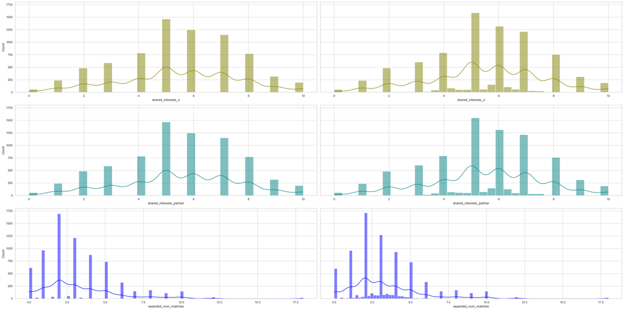

```python
fig,axs = plt.subplots(3,2, figsize = (32,16), sharey = True)

sns.histplot(data=df, x='shared_interests_o', kde = True,color="olive", ax=axs[0, 0])
sns.histplot(data=df_final, x="shared_interests_o",kde = True, color="olive", ax=axs[0, 1])
sns.histplot(data=df, x="shared_interests_partner",kde = True ,color="teal", ax=axs[1, 0])
sns.histplot(data=df_final, x="shared_interests_partner", kde=True, color="teal", ax=axs[1, 1])
sns.histplot(data=df, x="expected_num_matches", kde=True, color="blue", ax=axs[2, 0])
sns.histplot(data=df_final, x="expected_num_matches", kde=True, color="blue", ax=axs[2, 1])
fig.tight_layout()
```

# Corrélation entre 'met' et 'match' :

On se rend compte grâce à l'histogramme suivant que si deux individus se sont rencontrés avant le date, alors ils ont beaucoup plus de chance de matcher.

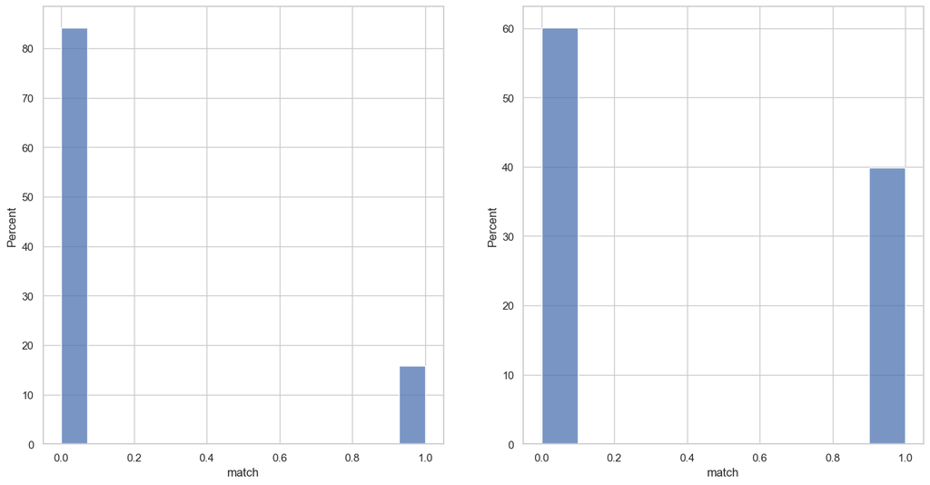

```python
fig,axs = plt.subplots(1,2, figsize = (16,8))

sns.histplot(data = df[df['met']==0], x = 'match', stat = 'percent', ax = axs[0])
sns.histplot(data = df[df['met']==1], x = 'match', stat = 'percent', ax = axs[1])
```

# Modification du nom de certaines variables :

```python
df = df_final.copy()
```

Certaines variables ont des noms avec un orthographe très tordu. Pour éviter des fautes de syntaxe, on les renomme de façon homogène.

```python
df = df.rename(columns={'sinsere_o':'sincere_o','ambitous_o':'ambition_o','pref_o_ambitious':'pref_o_ambition',
                        'intellicence_important':'intelligence_important','ambtition_important':'ambition_important'})
```

# Modification de certaines variables :

## Pour la variables d_age :

Les valeures manquantes de la variable âge était traitées comme des 0. Et 'd_age' était calculé en valeur absolue. Ce qui avait pour conséquence : - Perte d'information car on ne sait pas si c'est 'self' ou 'partner' qui est le plus agé. - Si on a l'age de 'self' et une valeur manquante pour 'partner', d_age valait l'age de 'self'. On recréer donc la variable 'd_age' après imputations des valeurs manquantes, et on garde maintenant l'information du signe dans la différence. (on effectue toujours l'age de l'homme - l'age de la femme).

```python
for i in range(len(df)):
    if df.iloc[i]['gender'] == 1:
        df.iloc[i]['d_age'] = df.iloc[i]['age'] - df.iloc[i]['age_o']
    else :
        df.iloc[i]['d_age'] = - df.loc[i]['age'] + df.iloc[i]['age_o']
```

## Pour la variable 'samerace' :

On encode à nouveau ici la variable 'samerace' après imputation des valeurs manquantes. En effet, quand 2 individus avaient la modalité 'Other', 'samerace' prennait la valeur 1. On prend ici la décision de dire que 2 individus ayant la modalité 'Other' ne partagent pas la même race.

```python
for i in range(len(df)):
    if df.iloc[i]['race'] == 4 and df.iloc[i]['race_o'] == 4:
        df.iloc[i]['samerace'] = 0
```

# Création de nouvelles variables :

## Création de la variable 'note_partner' qui représente l'estime que 'self' a envers 'partner' :

- C'est en quelque sorte la note générale que 'self' mettrait a 'partner'.

Pour calculer cette note, nous avons pondéré l'importance que 'self' accorde a certaines qualités (l'attractivité, la sincerité, l'intelligence, le fait d'être drôle, l'ambition) avec les notes qu'il a mise à 'partner' sur ces mêmes qualités.

```python
df['note_partner']=(df['attractive_partner']*df['attractive_important']+
                     df['sincere_partner']*df['sincere_important'] +
                     df['intelligence_partner']*df['intelligence_important']+
                     df['funny_partner']*df['funny_important'] +
                     df['ambition_partner']*df['ambition_important'])/(df['attractive_important']+df['sincere_important'] +df['intelligence_important']+df['funny_important']+df['ambition_important'])
```

## Création de la variable 'note_from_partner' qui est l'estime que 'partner' a en 'self' :

- C'est en quelque sorte la note générale que 'partner' mettrait a 'self'.

Pour calculer cette note, nous avons pondéré l'importance que 'partner' accorde a certaines qualités (l'attractivité, la sincerité, l'intelligence, le fait d'être drôle, l'ambition) avec les notes qu'il a mise à 'self' sur ces mêmes qualités.

```python
df['note_from_partner']=(df['attractive_o']*df['pref_o_attractive']+
                     df['sincere_o']*df['pref_o_sincere'] +
                     df['intelligence_o']*df['pref_o_intelligence']+
                     df['funny_o']*df['pref_o_funny'] +
                     df['ambition_o']*df['pref_o_ambition'])/(df['pref_o_attractive']+df['pref_o_sincere'] +df['pref_o_intelligence']+df['pref_o_funny']+df['pref_o_ambition'])
```

```python
df['note_partner'] = round(df['note_partner'],1)
df['note_from_partner'] = round(df['note_from_partner'],1)
```

Pour créer cette nouvelle variable, on va sommer, pour chaque match, la note générale que self a mise à partner au carré et la note que partner a mise a self au carré. En fait, le fait d'appliquer un carré met un poids sur les notes. Plus la note générale sera haute, plus le poids sera important. On va donc se retrouver avec un nombre qui sera un indicateur de "à quel point les deux participants s'apprécient".

```python
df['note_diff'] = df['note_partner']*df['note_partner']+ df['note_from_partner']*df['note_from_partner']
df
```

|  | gender | age | age_o | d_age | race | race_o | samerace | importance_same_race | importance_same_religion | pref_o_attractive | ... | expected_num_matches | like | guess_prob_liked | met | decision | decision_o | match | note_partner | note_from_partner | note_diff |
| --- | --- | --- | --- | --- | --- | --- | --- | --- | --- | --- | --- | --- | --- | --- | --- | --- | --- | --- | --- | --- | --- |
| 0 | 0.0 | 21.0 | 27.0 | 6.0 | 0.0 | 3.0 | 0.0 | 2.0 | 4.0 | 35.0 | ... | 4.0 | 7.0 | 6.0 | 0.0 | 1.0 | 0.0 | 0.0 | 7.1 | 7.3 | 103.70 |
| 1 | 0.0 | 21.0 | 22.0 | 1.0 | 0.0 | 3.0 | 0.0 | 2.0 | 4.0 | 60.0 | ... | 4.0 | 7.0 | 5.0 | 1.0 | 1.0 | 0.0 | 0.0 | 7.1 | 7.0 | 99.41 |
| 2 | 0.0 | 21.0 | 22.0 | 1.0 | 0.0 | 0.0 | 1.0 | 2.0 | 4.0 | 19.0 | ... | 4.0 | 7.0 | 5.2 | 1.0 | 1.0 | 1.0 | 1.0 | 7.2 | 10.0 | 151.84 |
| 3 | 0.0 | 21.0 | 23.0 | 2.0 | 0.0 | 3.0 | 0.0 | 2.0 | 4.0 | 30.0 | ... | 4.0 | 7.0 | 6.0 | 0.0 | 1.0 | 1.0 | 1.0 | 6.8 | 7.9 | 108.65 |
| 4 | 0.0 | 21.0 | 24.0 | 3.0 | 0.0 | 2.0 | 0.0 | 2.0 | 4.0 | 30.0 | ... | 4.0 | 6.0 | 6.0 | 0.0 | 1.0 | 1.0 | 1.0 | 6.2 | 8.0 | 102.44 |
| ... | ... | ... | ... | ... | ... | ... | ... | ... | ... | ... | ... | ... | ... | ... | ... | ... | ... | ... | ... | ... | ... |
| 8237 | 1.0 | 25.0 | 26.0 | -1.0 | 3.0 | 2.0 | 0.0 | 1.0 | 1.0 | 10.0 | ... | 3.0 | 2.0 | 5.0 | 0.0 | 0.0 | 1.0 | 0.0 | 3.6 | 4.2 | 30.60 |
| 8238 | 1.0 | 25.0 | 24.0 | 1.0 | 3.0 | 4.0 | 0.0 | 1.0 | 1.0 | 50.0 | ... | 3.0 | 4.0 | 4.0 | 0.0 | 0.0 | 0.0 | 0.0 | 4.6 | 5.4 | 50.32 |
| 8239 | 1.0 | 25.0 | 29.0 | -4.0 | 3.0 | 2.0 | 0.0 | 1.0 | 1.0 | 40.0 | ... | 3.0 | 6.0 | 5.0 | 0.0 | 0.0 | 0.0 | 0.0 | 5.2 | 1.9 | 30.65 |
| 8240 | 1.0 | 25.0 | 22.0 | 3.0 | 3.0 | 0.0 | 0.0 | 1.0 | 1.0 | 10.0 | ... | 3.0 | 5.0 | 5.0 | 0.0 | 0.0 | 1.0 | 0.0 | 4.2 | 5.4 | 46.80 |
| 8241 | 1.0 | 25.0 | 22.0 | 3.0 | 3.0 | 0.0 | 0.0 | 1.0 | 1.0 | 20.0 | ... | 3.0 | 4.0 | 5.0 | 0.0 | 0.0 | 1.0 | 0.0 | 3.6 | 7.6 | 70.72 |

8242 rows × 50 columns

On décide de normaliser cette nouvelle variable entre 0 et 1.

```python
df['note_diff'] = (df['note_diff'] - df['note_diff'].min())/(df['note_diff'].max() - df['note_diff'].min())
```

# Un peu de visualisation :

## Sur les variables 'note_partner' et 'note_from_partner' :

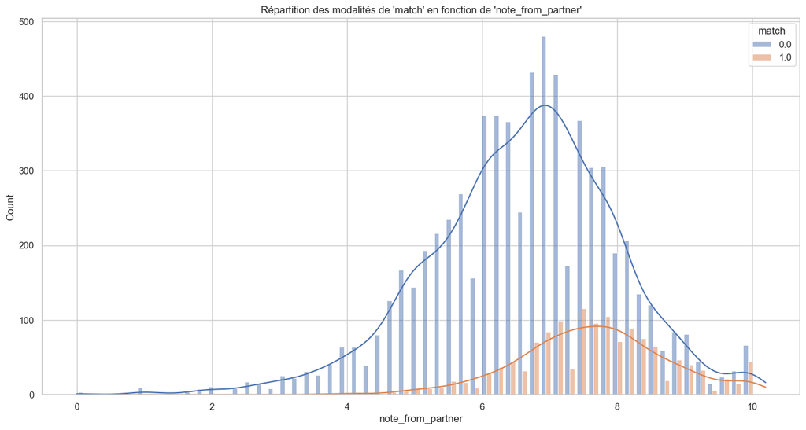

```python
plt.figure(figsize = (16,8))
plt.title("Répartition des modalités de 'match' en fonction de 'note_from_partner'")
sns.histplot(data = df, x = 'note_from_partner', kde = True, hue = 'match',  multiple = 'dodge', shrink = .8)
```

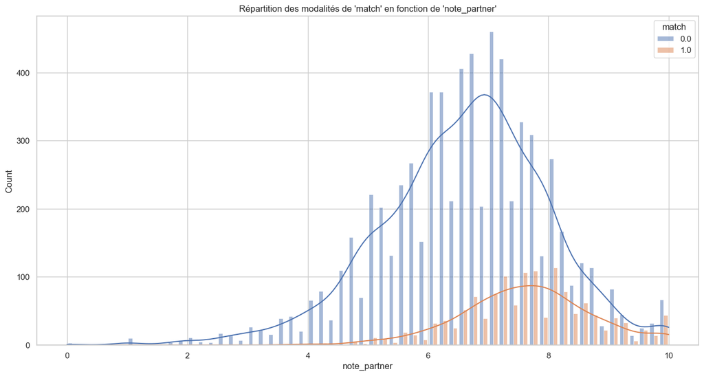

```python
plt.figure(figsize = (16,8))
plt.title("Répartition des modalités de 'match' en fonction de 'note_partner'")
sns.histplot(data = df, x = 'note_partner', kde = True, hue = 'match',  multiple = 'dodge', shrink = .8)
```

Les deux graphiques nous apprennent la même chose :

- Si la note générale que self (resp. partner) met à partner (resp. self) ne dépasse pas 7, alors il n'y aura probablement pas de match.
- Si la note générale que self (resp. partner) met à partner (resp. self) tourne autour de 8, cela maximise les chances d'avoir un match.

## Sur la variable 'note_diff' :

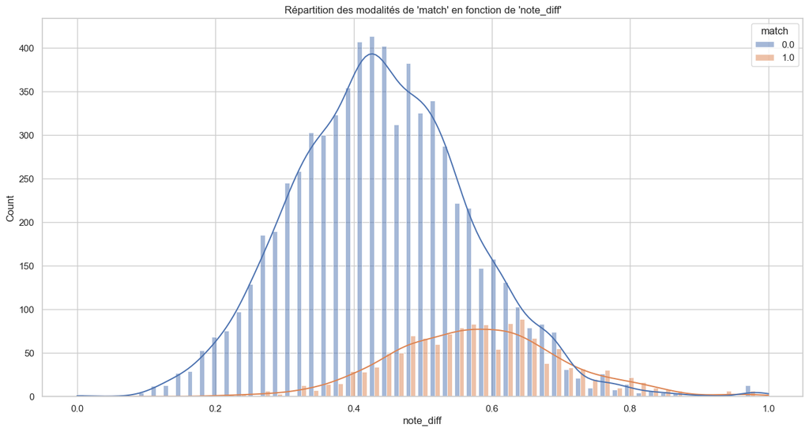

```python
plt.figure(figsize = (16,8))
plt.title("Répartition des modalités de 'match' en fonction de 'note_diff'")
sns.histplot(data = df, x = 'note_diff', kde = True, hue='match',  multiple = 'dodge', shrink = .8)
```

Le graphique ci-dessus nous apprend trois choses :

- Si 'note_diff' est trop faible, on a aucune chance de match.
- Si 'note_diff' tourne autour de 0.4, il n'y aura probablement pas de match.
- Si 'note_diff' dépasse 0.6, on a de + en + de chance d'avoir un match.

## Comparaison de la notation entre les hommes et les femmes :

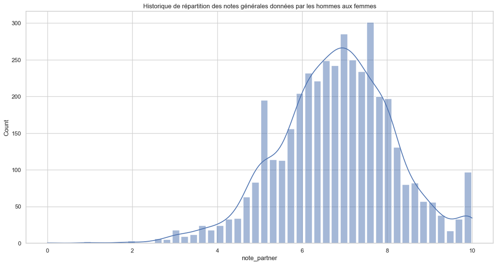

```python
plt.figure(figsize = (16,8))
plt.title("Historique de répartition des notes générales données par les hommes aux femmes")
sns.histplot(data = df[df['gender']==1], x = 'note_partner', kde = True, multiple = 'dodge', shrink = .8)
```

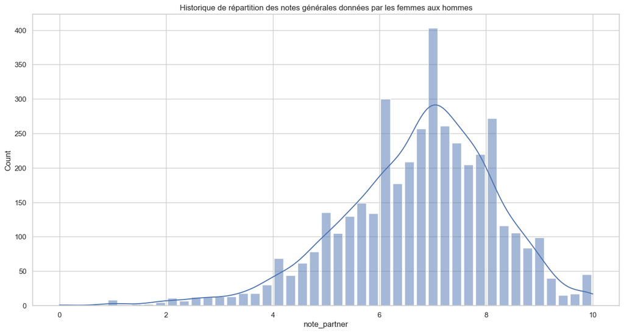

```python
plt.figure(figsize = (16,8))
plt.title("Historique de répartition des notes générales données par les femmes aux hommes")
sns.histplot(data = df[df['gender']==0], x = 'note_partner', kde = True, multiple = 'dodge', shrink = .8)
```

## Répartition des modalités de la variable 'match' :

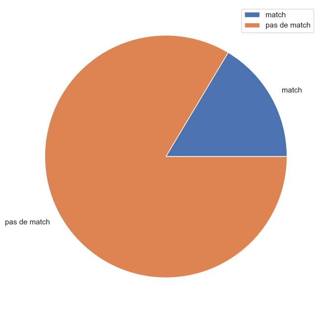

```python
import matplotlib.pyplot as plt
plt.figure(figsize = (16,8))
plt.pie([df[df['match']==1].shape[0],df[df['match']==0].shape[0]], labels = ["match","pas de match"], normalize = True)
plt.legend()
```

# On sauvegarde le dataset nettoyé sous format .csv ! On s'attaquera à la partie Machine Learning dans un second fichier.

```python
data_to_csv = df.to_csv('data_clean.csv')
```